# **A Comparison of Different Convolutional Neural Network Architectures for Dog Breed Classification**

## **Abstract**

> This tutorial demonstrates and explains the creation of various different convolutional neural networks for dog breed classification. The networks are trained on the "Stanford dogs" dataset and implemented using pytorch. This dataset and problem suits a machine learning approach, as dog breeds are often similar and require expert knowledge of features to distinguish.

> This tutorial will cover the full machine learning pipeline, starting with data loading and pre-processing, before moving on to the network creation and training. The networkss will be evaluated and improved using hyperparameter tuning, and these results will be visualised and compared using the Matplotlib library, to compare model performance.

## **Learning Objectives**

> Upon completion of this tutorial, you should be able to:
> - Understand the role of Convolutional Neural Networks (CNNs) in image classification
> - Process image data for use in a neural network using pytorch torchvision
> - Build a CNN using pytorch, understanding its layers
> - Implement a training process for your CNN
> - Build upon the CNNs architecture to improve performance
> - Understand how hyperparameter tuning impacts the model's performance
> - Understand how pre-trained models can be adapted to solve specific problems
> - Visualise and understand the results of your network's training process

## **Contents**

1. Comparison to Existing Tutorials
2. Setting up the Environment
3. Data Loading and Preprocessing  
   3.1 Data Loading  
   3.2 Data Transformation  
   3.3 Splitting the Dataset  
   3.4 Data Loaders
4. Training and Improving CNN  
   4.1 Network Architecture  
   4.2 Training and Evaluation Function  
   4.3 Improving Network Architecture  
   4.4 Using Pre-Trained Models
5. Comparison of Models
6. Hyperparameter Optimisation  
   6.1 Learning Rate  
   6.2 Optimiser
7. Bibliography

## **Comparison to existing tutorials**

This tutorial will have different focuses to those currently existing:

| What we will focus on | What other tutorials may explain in more detail | Tutorials which cover this in more depth |
| --- | --- | --- |
| Image data loading and Pre-processing | Oversampling and undersampling, as dataset is already balanced | [Handling Imbalanced Data for Classification - geeksforgeeks.org](https://www.geeksforgeeks.org/handling-imbalanced-data-for-classification/) |
| Explanation of PyTorch and torchvision | General Python explanation and environment setup - basic syntax experience is assumed | [Python for Beginners - python.org](https://www.python.org/about/gettingstarted/) |
| How to Optimise Hyperparameters | Testing every possible combination | [Hyperparameter tuning - geeksforgeeks.org](https://www.geeksforgeeks.org/hyperparameter-tuning/) |
| Integration of Pre-trained Models |  |  |

## **Setting up the Environment**

Before we begin building and training our neural network pipeline, we should import the core libraries we will be using most frequently:

```python
import torch  # Core deep learning library
import torch.nn as nn  # Allows for neural networks to be defined
import matplotlib.pyplot as plt  # Visualization of training process and results
import numpy as np  # Numerical computation and array operations

print("Torch version:", torch.__version__)
print("NumPy version:", np.__version__)
```

```
Torch version: 2.6.0+cpu
NumPy version: 2.2.3
```

## **Data Loading and Preprocessing**

### **Data Loading**

> The dataset being used for this tutorial is the "Stanford dogs" dataset. This dataset lends itself well to this task as it has over 20000 images of 120 breeds of dog, and is mostly evenly balanced.

> The dataset can be downloaded from the official stanford website (stanford.edu), or alternatively from kaggle (https://www.kaggle.com/datasets/miljan/stanford-dogs-dataset-traintest). In this example, I have downloaded from the latter, as it contains the dogs already sorted into folders corresponding to their breed.

```python
import os # Required to use system folders
import torchvision # Library for image processing in neural networks
from torchvision import datasets # Library for creating a dataset of images
```

```python
Data_Directory = "images/"
# Change file path to the location of your dataset
dataset = datasets.ImageFolder(root=Data_Directory)
```

**By using torchvision dataset's image folder function, we automatically assign each class label to all images within its folder**

```python
breeds = dataset.classes
number_of_breeds = len(breeds)

print("The number of breeds classified by this dataset is", number_of_breeds)
print(f"These include: {breeds[:5]}")
```

```
The number of breeds classified by this dataset is 120
These include: ['n02085620-Chihuahua', 'n02085782-Japanese_spaniel', 'n02085936-Maltese_dog', 'n02086079-Pekinese', 'n02086240-Shih-Tzu']
```

**In order to improve readability, we can clean up these class names:**

```python
def clean_breed_name(breed):
    return "-".join(breed.split("-")[1:])  # Remove the first numeric part from the folder name

cleaned_breeds = [clean_breed_name(breed) for breed in dataset.classes]
print(f"Cleaned Breed Names (first 5): {cleaned_breeds[:5]}")
```

```
Cleaned Breed Names (first 5): ['Chihuahua', 'Japanese_spaniel', 'Maltese_dog', 'Pekinese', 'Shih-Tzu']
```

**As you can see below, our dataset is fully labelled and ready for pre-processing:**

[figure not shown]

```python
from PIL import Image

image_indices = [1,1000,2000]

fig, axes = plt.subplots(1, 3, figsize=(12, 4))

for i, idx in enumerate(image_indices):
    img_path, label = dataset.samples[idx]
    class_name = cleaned_breeds[label]  # Use cleaned breed name from previous cell

    # Load image using PIL (before transformation)
    img = Image.open(img_path)
    # Image formatting code
    axes[i].imshow(img)
    axes[i].set_title(class_name)
    axes[i].axis("off")

plt.show()
```

### **Data Transformation**

**Now that the dataset is loaded and labelled, we must now transform the images for training. This involves 3 key steps:**  
1. Resizing images for consistency - the standard for CNNs is 224x224  
2. Normalising pixel values - improves training stability  
3. Data augmentation - this helps the model generalise better

```python
from torchvision import transforms # Must import transforms library

# Define transformations for training data
transform_train = transforms.Compose([
    transforms.Resize((224, 224)),  # Resize all images to 224x224 - this is the standard for CNNs
    transforms.RandomHorizontalFlip(),  # Augmentation step
    transforms.ToTensor(),
    transforms.Normalize(mean=[0.485, 0.456, 0.406], std=[0.229, 0.224, 0.225])  # Normalize
])

# Define transformations for validation data - augmentation not needed
transform_val = transforms.Compose([
    transforms.Resize((224, 224)),
    transforms.ToTensor(),
    transforms.Normalize(mean=[0.485, 0.456, 0.406], std=[0.229, 0.224, 0.225])
])
```

### **Splitting the Dataset**

Dataset must be split in order to ensure independence from the training set when testing the network. This avoids data leakage, as otherwise the network may not be generalisng but instead recalling.

It is standard practise to divide data into 80% training and 20% validation. This can be achieved easily using torch's built in random split functionality.

```python
from torch.utils.data import random_split

train_size = int(0.8 * len(dataset))
val_size = len(dataset) - train_size

train_dataset, val_dataset = random_split(dataset, [train_size, val_size])
```

We now apply our transformations we defined earlier to the training and validation sets

[figure not shown]

```python
train_dataset.dataset.transform = transform_train
val_dataset.dataset.transform = transform_val

num_images = 2
image_indices = [1000,2000]

fig, axes = plt.subplots(num_images, 2, figsize=(8, 6))  # 2 columns: original (left) & transformed (right)

for i, idx in enumerate(image_indices):
    img_path, label = dataset.samples[idx]  # Get image path and label
    class_name = cleaned_breeds[label]  # Use cleaned breed name

    # Load original image (before transformation)
    img_before = Image.open(img_path)

    # Apply the corresponding transformation (train version)
    img_after = transform_train(img_before)

    # Convert transformed tensor image back to a NumPy array for visualization
    img_after = img_after.permute(1, 2, 0).numpy()  # Convert (C, H, W) to (H, W, C)
    img_after = np.clip(img_after, 0, 1)
    # Show the original image (Left Column)
    axes[i, 0].imshow(img_before)
    axes[i, 0].set_title(f"Original: {class_name}")
    axes[i, 0].axis("off")

    # Show the transformed image (Right Column)
    axes[i, 1].imshow(img_after)
    axes[i, 1].set_title("Transformed")
    axes[i, 1].axis("off")

plt.suptitle("Original vs Transformed Images", fontsize=14)
plt.show()
```

### **Data Loaders**

Now that the dataset is split appropriately, we need to create data loaders to allow for the network to be trained on them.

```python
from torch.utils.data import DataLoader

train_loader = DataLoader(train_dataset, batch_size=32, shuffle=True, num_workers=os.cpu_count()-1, pin_memory=True)
val_loader = DataLoader(val_dataset, batch_size=32, shuffle=False, num_workers=os.cpu_count()-1, pin_memory=True)
```

**Batch size**: 32 is a standard size batch, however this can be increased or decreased based on the memory of the CPU/GPU  
**Shuffle**: shuffles training data for better generalisation, however not necessary on the validation set  
**Number of workers**: The number of cpu threads used for data loading

**We can check if the data loaders are working correctly by examining the shape of a batch of images:**

- The image batch shape should be 32 x (3x224x224) as this is the size of the transformed images
- The label batch shape should be 32

```python
data_iter = iter(train_loader)
images, labels = next(data_iter)

print(f"Image batch shape: {images.shape}")
print(f"Label batch shape: {labels.shape}")
```

```
Image batch shape: torch.Size([32, 3, 224, 224])
Label batch shape: torch.Size([32])
```

## **Training and Improving CNN**

### **Network Architecture**

We define our initial simple network to have two convolutional layers, one pooling layer and one fully connected layer - we will build upon this later

```python
import torch.nn.functional as F

class basicCNN(nn.Module):
    def __init__(self, num_classes):
        super(basicCNN, self).__init__()
        self.conv1 = nn.Conv2d(3, 32, kernel_size=3, stride=1, padding=1)
        self.conv2 = nn.Conv2d(32, 64, kernel_size=3, stride=1, padding=1)
        self.pool = nn.MaxPool2d(2, 2)
        self.fc1 = nn.Linear(64 * 56 * 56, num_classes)

    def forward(self, x):
        x = self.pool(F.relu(self.conv1(x)))
        x = self.pool(F.relu(self.conv2(x)))
        x = torch.flatten(x, start_dim=1)
        x = self.fc1(x)
        return x

print("Basic CNN defined")
```

```
Basic CNN defined
```

### **Training and Evaluation Function**

```python
import torch
import torch.nn as nn
import torch.optim as optim

import torch.backends.cudnn as cudnn
cudnn.benchmark = True

def train_and_evaluate(model, num_epochs=5):
    device = torch.device("cuda" if torch.cuda.is_available() else "cpu")
    model.to(device)

    criterion = nn.CrossEntropyLoss()
    optimizer = optim.SGD(model.parameters(), lr=0.01, momentum=0.9)

    losses = []

    for epoch in range(num_epochs):
        model.train()
        running_loss = 0.0

        for images, labels in train_loader:
            images, labels = images.to(device), labels.to(device)

            optimizer.zero_grad()
            outputs = model(images)
            loss = criterion(outputs, labels)
            loss.backward()
            optimizer.step()

            running_loss += loss.item()

        avg_loss = running_loss / len(train_loader)
        losses.append(avg_loss)

    # Evaluation Phase
    model.eval()
    correct = 0
    total = 0

    with torch.no_grad():
        for images, labels in val_loader:
            images, labels = images.to(device), labels.to(device)
            outputs = model(images)
            _, predicted = torch.max(outputs, 1)
            total += labels.size(0)
            correct += (predicted == labels).sum().item()

    accuracy = 100 * correct / total
    return accuracy, losses
```

```python
num_classes = len(dataset.classes)
basic_model = basicCNN(num_classes)
basicepochs = 30
basic_cnn_accuracy, basic_losses = train_and_evaluate(basic_model, basicepochs)

print(f"\nFinal Accuracy of BasicCNN: {basic_cnn_accuracy:.2f}%")
```

```
Final Accuracy of BasicCNN: 9.43%
```

### **Improving Network Architecture**

Due to only having 2 convolutional layers, this network struggles to generalise the images and therefore produces a very low accuracy in testing. We can fix this by using an improved neural network structure.

```python
class ImprovedCNN(nn.Module):
    def __init__(self, num_classes):
        super(ImprovedCNN, self).__init__()

        self.features = nn.Sequential(
            # Block 1
            nn.Conv2d(3, 64, kernel_size=3, padding=1),
            nn.ReLU(inplace=True),
            nn.Conv2d(64, 64, kernel_size=3, padding=1),
            nn.ReLU(inplace=True),
            nn.MaxPool2d(kernel_size=2, stride=2),  # Downsample to 112x112

            # Block 2
            nn.Conv2d(64, 128, kernel_size=3, padding=1),
            nn.ReLU(inplace=True),
            nn.Conv2d(128, 128, kernel_size=3, padding=1),
            nn.ReLU(inplace=True),
            nn.MaxPool2d(kernel_size=2, stride=2),  # Downsample to 56x56

            # Block 3
            nn.Conv2d(128, 256, kernel_size=3, padding=1),
            nn.ReLU(inplace=True),
            nn.Conv2d(256, 256, kernel_size=3, padding=1),
            nn.ReLU(inplace=True),
            nn.Conv2d(256, 256, kernel_size=3, padding=1),
            nn.ReLU(inplace=True),
            nn.MaxPool2d(kernel_size=2, stride=2),  # Downsample to 28x28

            # Block 4
            nn.Conv2d(256, 512, kernel_size=3, padding=1),
            nn.ReLU(inplace=True),
            nn.Conv2d(512, 512, kernel_size=3, padding=1),
            nn.ReLU(inplace=True),
            nn.Conv2d(512, 512, kernel_size=3, padding=1),
            nn.ReLU(inplace=True),
            nn.MaxPool2d(kernel_size=2, stride=2),  # Downsample to 14x14

            # Block 5
            nn.Conv2d(512, 512, kernel_size=3, padding=1),
            nn.ReLU(inplace=True),
            nn.Conv2d(512, 512, kernel_size=3, padding=1),
            nn.ReLU(inplace=True),
            nn.Conv2d(512, 512, kernel_size=3, padding=1),
            nn.ReLU(inplace=True),
            nn.MaxPool2d(kernel_size=2, stride=2),  # Downsample to 7x7
        )

        self.classifier = nn.Sequential(
            nn.Linear(512 * 7 * 7, 4096),
            nn.ReLU(inplace=True),
            nn.Dropout(0.5),
            nn.Linear(4096, 4096),
            nn.ReLU(inplace=True),
            nn.Dropout(0.5),
            nn.Linear(4096, num_classes),
        )

    def forward(self, x):
        x = self.features(x)
        x = torch.flatten(x, start_dim=1)
        x = self.classifier(x)
        return x

print("Improved model defined")
```

```
Improved model defined
```

```python
improved_cnn_model = ImprovedCNN(num_classes=len(dataset.classes))
improvedepochs = 20
improved_cnn_accuracy, improved_losses = train_and_evaluate(improved_cnn_model, improvedepochs)
print(f"\nFinal Accuracy of Improved CNN: {improved_cnn_accuracy:.2f}%")
```

```
Final Accuracy of Improved CNN: 59.72%
```

This is a significant improvement on the initial model

### **Using Pre-Trained Models**

To improve accuracy and also reduce computation time, we can use pre-trained models and fine-tune them specifically for our dataset. By using the torchvision "models" library, we can import the ResNet18 model, which has proven to be effective on image databases (He et al 2016). We then only update the final layer during training, which greatly reduces computational cost:

```python
import torchvision.models as models
from torchvision.models import ResNet18_Weights

class ResNet18(nn.Module):
    def __init__(self, num_classes):
        super(ResNet18, self).__init__()

        # Load pretrained model using the updated weights format
        self.model = models.resnet18(weights=ResNet18_Weights.DEFAULT)

        # Freeze all layers except the final one
        for param in self.model.parameters():
            param.requires_grad = False  # Do not update pretrained layers

        # Replace the final fully connected layer with one for our number of classes
        self.model.fc = nn.Linear(self.model.fc.in_features, num_classes)

    def forward(self, x):
        return self.model(x)

print("ResNet18 model loaded & adapted")
```

```
ResNet18 model loaded & adapted
```

```python
resnet_model = ResNet18(num_classes)
resnetepochs = 5
resnet_accuracy, resnet_losses = train_and_evaluate(resnet_model, resnetepochs)
print(f"\n Final ResNet18 Accuracy: {resnet_accuracy:.2f}%")
```

```
 Final ResNet18 Accuracy: 74.56%
```

```python
torch.save(resnet_model.state_dict(), "resnet18_dog_breed_classifier.pth")
print("Model saved successfully!")
```

```
Model saved successfully!
```

**We can then reload the model and use it to classify new images whenever we need**

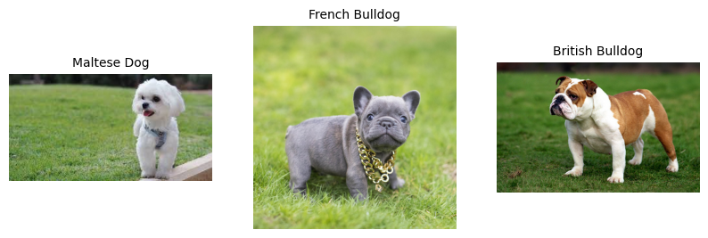

```python
image_paths = ["images/new1.jpg", "images/new2.jpg", "images/new3.jpg"]

labels = ["Maltese Dog", "French Bulldog", "British Bulldog"]

transform = transforms.Compose([
    transforms.Resize((224, 224)),
    transforms.ToTensor(),
    transforms.Normalize(mean=[0.485, 0.456, 0.406], std=[0.229, 0.224, 0.225])
])

fig, axes = plt.subplots(1, 3, figsize=(10, 5))
for i, (image_path, label) in enumerate(zip(image_paths, labels)):
    img = Image.open(image_path).convert("RGB")
    axes[i].imshow(img)
    axes[i].axis("off")
    axes[i].set_title(label, fontsize=10)
plt.show()
```

```python
num_classes = len(dataset.classes)  # Ensure same number of classes as before
loaded_model = ResNet18(num_classes)
loaded_model.load_state_dict(torch.load("resnet18_dog_breed_classifier.pth"))
loaded_model.eval()  # Set model to evaluation mode
print("Model loaded successfully!")
```

```
Model loaded successfully!
```

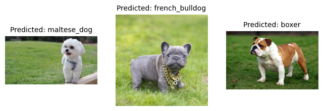

```python
def predict_images(model, image_paths):
    device = torch.device("cuda" if torch.cuda.is_available() else "cpu")
    model.to(device)
    model.eval()

    predictions = []

    for image_path in image_paths:
        img = Image.open(image_path).convert("RGB")
        img_tensor = transform(img).unsqueeze(0).to(device)

        with torch.no_grad():
            output = model(img_tensor)
            _, predicted = torch.max(output, 1)

        class_name = cleaned_breeds[predicted.item()]
        predictions.append(class_name)

    return predictions

predicted_classes = predict_images(loaded_model, image_paths)

fig, axes = plt.subplots(1, 3, figsize=(8, 4))
for i, (image_path, class_name) in enumerate(zip(image_paths, predicted_classes)):
    img = Image.open(image_path).convert("RGB")
    axes[i].imshow(img)
    axes[i].axis("off")
    axes[i].set_title(f"Predicted: {class_name}", fontsize=10)

plt.show()
```

## **Comparison of Models**

We can compare our three models in terms of required training time and validation accuracy. We use matplotlib to visualise these results.

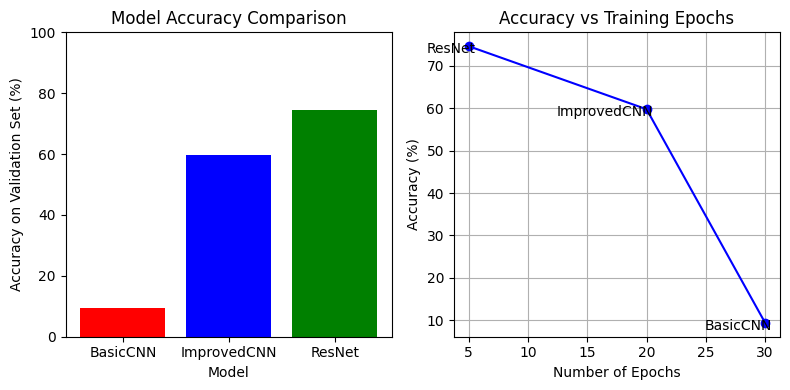

```python
models = ["BasicCNN", "ImprovedCNN", "ResNet"]
accuracies = [basic_cnn_accuracy, improved_cnn_accuracy, resnet_accuracy]
epochs = [basicepochs, improvedepochs, resnetepochs]

fig, axes = plt.subplots(1, 2, figsize=(8, 4))

axes[0].bar(models, accuracies, color=['red', 'blue', 'green'])
axes[0].set_xlabel("Model")
axes[0].set_ylabel("Accuracy on Validation Set (%)")
axes[0].set_title("Model Accuracy Comparison")
axes[0].set_ylim(0, 100)

axes[1].plot(epochs, accuracies, marker='o', linestyle='-', color='blue')
axes[1].set_xlabel("Number of Epochs")
axes[1].set_ylabel("Accuracy (%)")
axes[1].set_title("Accuracy vs Training Epochs")
axes[1].grid(True)

for i, model in enumerate(models):
    axes[1].annotate(model, (epochs[i], accuracies[i]), textcoords="offset points", xytext=(5,-5), ha='right')

plt.tight_layout()
plt.show()
```

As shown above, adding more convolutional layers, either manually or by using a large pre-trained network, results in much higher accuracy and allows the network to learn trends quicker. The pre-trained network in particular is great for reducing computational time. We can show this faster learning using a graph with epochs vs training loss:

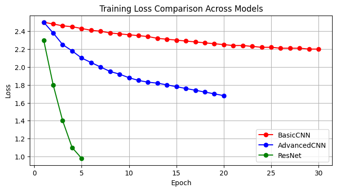

```python
epochs_basic = list(range(1, len(basic_losses) + 1))
epochs_advanced = list(range(1, len(advanced_losses) + 1))
epochs_resnet = list(range(1, len(resnet_losses) + 1))

plt.figure(figsize=(8, 4))
plt.plot(epochs_basic, basic_losses, marker='o', linestyle='-', color='red', label="BasicCNN")
plt.plot(epochs_advanced, advanced_losses, marker='o', linestyle='-', color='blue', label="AdvancedCNN")
plt.plot(epochs_resnet, resnet_losses, marker='o', linestyle='-', color='green', label="ResNet")

plt.xlabel("Epoch")
plt.ylabel("Loss")
plt.title("Training Loss Comparison Across Models")
plt.legend()
plt.grid(True)

plt.show()
```

## **Hyperparameter Optimisation**

We can fine tune the network's performance by updating the training function to use different combinations of hyperparameters. For this section we will be using the ResNet network, due to its faster execution and higher accuracy. Note that the original network had an accuracy of 74.56% when using a learning rate of 0.01, and the SGD optimiser.

### **Learning Rate**

To change the learning rate, we can update our training and evaluation function to take learning rate as a parameter:

```python
cudnn.benchmark = True

def train_and_evaluate_lr(model, lr, num_epochs=5):
    device = torch.device("cuda" if torch.cuda.is_available() else "cpu")
    model.to(device)

    criterion = nn.CrossEntropyLoss()
    optimizer = optim.SGD(model.parameters(), lr=lr, momentum=0.9) # Learning rate is used here

    losses = []

    for epoch in range(num_epochs):
        model.train()
        running_loss = 0.0

        for images, labels in train_loader:
            images, labels = images.to(device), labels.to(device)

            optimizer.zero_grad()
            outputs = model(images)
            loss = criterion(outputs, labels)
            loss.backward()
            optimizer.step()

            running_loss += loss.item()

        avg_loss = running_loss / len(train_loader)
        losses.append(avg_loss)

    # Evaluation Phase
    model.eval()
    correct = 0
    total = 0

    with torch.no_grad():
        for images, labels in val_loader:
            images, labels = images.to(device), labels.to(device)
            outputs = model(images)
            _, predicted = torch.max(outputs, 1)
            total += labels.size(0)
            correct += (predicted == labels).sum().item()

    accuracy = 100 * correct / total
    return accuracy, losses
```

We can then call this function with various different learning rates and analyse the results:

```python
lr2_accuracy, lr3_losses = train_and_evaluate_lr(resnet_model, 0.005, 10)
lr3_accuracy, lr3_losses = train_and_evaluate_lr(resnet_model, 0.001, 20)
```

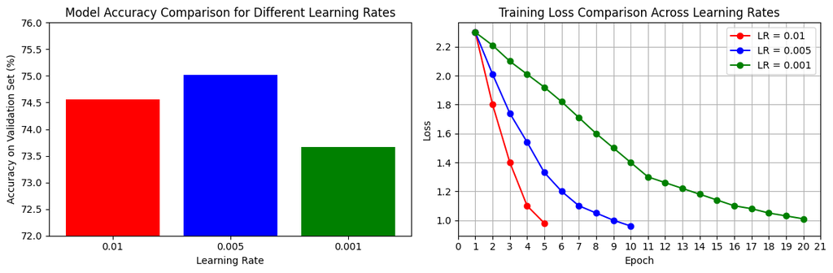

```python
models = ["0.01", "0.005", "0.001"]
accuracies = [resnet_accuracy, lr2_accuracy, lr3_accuracy]

epochs_001 = list(range(1, len(resnet_losses) + 1))
epochs_0005 = list(range(1, len(lr2_losses) + 1))
epochs_0001 = list(range(1, len(lr3_losses) + 1))

fig, axes = plt.subplots(1, 2, figsize=(12, 4))

# Bar Chart: Accuracy Comparison
axes[0].bar(models, accuracies, color=['red', 'blue', 'green'])
axes[0].set_xlabel("Learning Rate")
axes[0].set_ylabel("Accuracy on Validation Set (%)")
axes[0].set_title("Model Accuracy Comparison for Different Learning Rates")
axes[0].set_ylim(72, 76)

axes[1].plot(epochs_001, resnet_losses, marker='o', linestyle='-', color='red', label="LR = 0.01")
axes[1].plot(epochs_0005, lr2_losses, marker='o', linestyle='-', color='blue', label="LR = 0.005")
axes[1].plot(epochs_0001, lr3_losses, marker='o', linestyle='-', color='green', label="LR = 0.001")
axes[1].set_xlim(0, 21)
axes[1].xaxis.set_major_locator(plt.MultipleLocator(1))
axes[1].set_xlabel("Epoch")
axes[1].set_ylabel("Loss")
axes[1].set_title("Training Loss Comparison Across Learning Rates")
axes[1].legend()
axes[1].grid(True)

plt.tight_layout()
plt.show()
```

As shown above, using a smaller rate can lead to better convergence, as the model will not "overshoot". However, decreasing the learning rate also increase the required training time, and decreasing it too much is not a worthwhile trade-off.

### **Optimiser**

We can also compare the models accuracy using different optimisers, instead using Adam rather than SGD:

```python
cudnn.benchmark = True

def train_and_evaluate_Adam(model, num_epochs=5):
    device = torch.device("cuda" if torch.cuda.is_available() else "cpu")
    model.to(device)

    criterion = nn.CrossEntropyLoss()
    # Changed from SGD to Adam optimizer
    optimizer = optim.Adam(model.parameters(), lr=0.01)

    losses = []

    for epoch in range(num_epochs):
        model.train()
        running_loss = 0.0

        for images, labels in train_loader:
            images, labels = images.to(device), labels.to(device)

            optimizer.zero_grad()
            outputs = model(images)
            loss = criterion(outputs, labels)
            loss.backward()
            optimizer.step()

            running_loss += loss.item()

        avg_loss = running_loss / len(train_loader)
        losses.append(avg_loss)

    model.eval()
    correct = 0
    total = 0

    with torch.no_grad():
        for images, labels in val_loader:
            images, labels = images.to(device), labels.to(device)
            outputs = model(images)
            _, predicted = torch.max(outputs, 1)
            total += labels.size(0)
            correct += (predicted == labels).sum().item()

    accuracy = 100 * correct / total
    return accuracy, losses
```

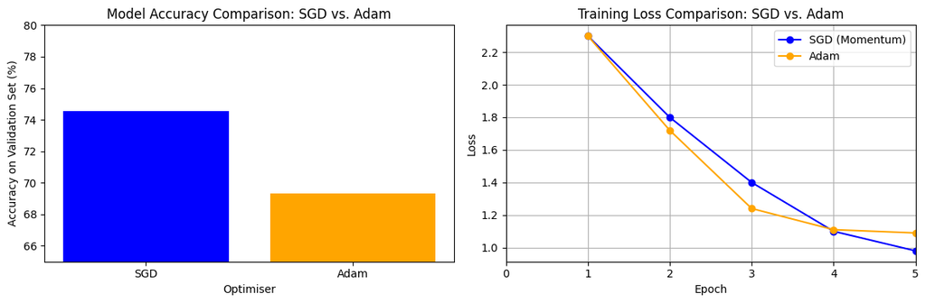

```python
adams_ accuracy, adams_losses = train_and_evaluate_Adam(resnet_model, resnetepochs)

import matplotlib.pyplot as plt

models = ["SGD", "Adam"]
accuracies = [resnet_accuracy, adam_accuracy]
epochs = list(range(1, len(resnet_losses) + 1))

fig, axes = plt.subplots(1, 2, figsize=(12, 4))

axes[0].bar(models, accuracies, color=['blue', 'orange'])
axes[0].set_xlabel("Optimiser")
axes[0].set_ylabel("Accuracy on Validation Set (%)")
axes[0].set_title("Model Accuracy Comparison: SGD vs. Adam")
axes[0].set_ylim(65, 80)

axes[1].plot(epochs, resnet_losses, marker='o', linestyle='-', color='blue', label="SGD (Momentum)")
axes[1].plot(epochs, adam_losses, marker='o', linestyle='-', color='orange', label="Adam")
axes[1].set_xlim(0, 5)
axes[1].xaxis.set_major_locator(plt.MultipleLocator(1))
axes[1].set_xlabel("Epoch")
axes[1].set_ylabel("Loss")
axes[1].set_title("Training Loss Comparison: SGD vs. Adam")
axes[1].legend()
axes[1].grid(True)

plt.tight_layout()
plt.show()
```

As demonstrated in the graph, the Adam optimiser converges quicker than SGD, however generalises worse in the long run. There are many different permutations of hyperparamters which can't all be covered by this tutorial, so feel free to experiment further with different combinations of learning rate and optimiser.

## **Bibliography**

### Research Papers

- Simonyan, K. and Zisserman, A. (2014). *Very deep convolutional networks for large-scale image recognition*.
- He, K., Zhang, X., Ren, S., and Sun, J. (2016). *Deep residual learning for image recognition*. In *Proceedings of the IEEE Conference on Computer Vision and Pattern Recognition*, pp. 770-778.

### Online Resources

- [Getting Started with Python](https://www.python.org/about/gettingstarted/)
- [Handling Imbalanced Data for Classification](https://www.geeksforgeeks.org/handling-imbalanced-data-for-classification/)
- [Hyperparameter Tuning](https://www.geeksforgeeks.org/hyperparameter-tuning/)